# Lab feature importance

```r
library(tidyverse)
wine <- read.table('./wine.txt', header = TRUE)
wine$class <- as.numeric(wine$class == 1)
```

We have explored the relationship between feature and target graphically, now we are going to measure it.

The deviance of a statistical model is computed in the following way: -2 (LL(model) - LL(saturated model)). Where the saturated model has a perfect fit, with a parameter for each observation. The null deviance is the deviance for an intercept-only model. The deviance reduction is the proportional difference between the model deviance and the null deviance. It has a similar meaning as the R squared, amount of variance explained by the model.

2.1 Fit a logistic regression model on a data set and obtain the deviance and null.deviance from it.

```r
mod <- glm(vs ~ cyl, data = mtcars, family = 'binomial')
mod$null.deviance
```

```
## [1] 43.86011
```

```r
mod$deviance
```

```
## [1] 17.95895
```

2.2 `glm` is a convenience wrapper over `glm.fit`, it allows you to feed it with a data frame, it will automatically add a column for the intercept and it gives the formula option so you can specify exactly what features to use. Moreover, it creates dummies from categorical variables. `glm.fit` however is easier to program with.

We are going to assess the individual deviance reduction for each of the features in the wine data set. Write a function that: - takes a feature as parameter. - makes a n x 2 matrix with a columns of 1s and the feature. - regress the wine class on the matrix with `glm.fit`. - returns the deviance reduction.

```r
# X = a data frame of one or more features
dev_reduction <- function(X){
  X_mat <- cbind(1, X) %>% as.matrix
  y <- wine$class
  mod <- glm.fit(X_mat, y, family = binomial())
  1 - mod$deviance / mod$null.deviance
}
```

2.3 Apply this function to all the features of the wine data set. Save in a data frame with two columns; the feature names and the deviance reduction. Use either a `for` loop or `sapply`

```r
dev_red <- wine %>% dplyr::select(-class) %>% sapply(dev_reduction)
dev_red_df <- data.frame(var = names(dev_red), dev_red = dev_red)
```

2.4 The object with relative information of the boosted model, shown in the slides, is saved in relative_information.Rdata (the object it loads is called rel_inf). Load it, join it to the data frame with deviance reduction and make a plot comparing the two.

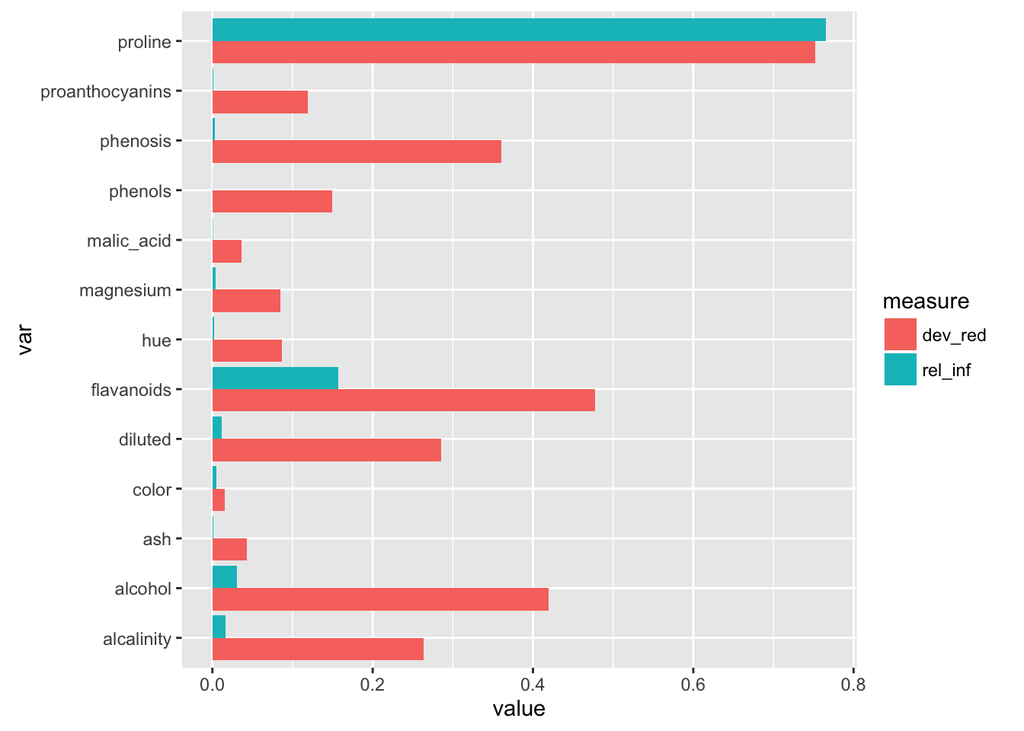

```r
load('./relative_information.Rdata')
full_join(dev_red_df, rel_inf) %>%
  gather(measure, value, -var) %>%
  ggplot(aes(var, value)) +
  geom_bar(aes(fill = measure), stat = 'identity', position = 'dodge') +
  coord_flip()
```

2.5 Can you explain the relative information being higher than the deviance reduction for proline ?

Answer: deviance reduction is a linear measuere, boosted trees fit nonlinear relationships. For completeness we could also check nonlinear univariate relations, for instance by allowing for polynomials in the glm.